# Clase 2. Kernels y Tendencia (OPCIONAL)

Juan Barriola y Sofía Perini[^1]

12 de Septiembre de 2020

### Kernels (OPCIONAL)

```r
library(tidyverse)
library(ggthemes)
```

Podemos hacer una nueva versión del gráfico 2. Utilizando un procesamiento similar al que hicimos antes.

```r
datagraf <- Individual_T120 %>%
  select(REGION,P47T,T_VI, TOT_P12, P21, PONDII, CH04) %>%
  filter(!is.na(P47T), P47T > 0 ) %>%
  mutate(REGION             = case_when(REGION == 1    ~ 'GBA',
                                        REGION == 40   ~ 'NOA',
                                        REGION == 41   ~ 'NEA',
                                        REGION == 42   ~ 'Cuyo',
                                        REGION == 43   ~ 'Pampeana',
                                        REGION == 44   ~ 'Patagonia',
                                        FALSE          ~ 'otro'),
         ingreso_laboral    = as.numeric(TOT_P12 + P21),
         ingreso_no_laboral = as.numeric(T_VI),
         CH04               = case_when(CH04 == 1 ~ "Varon",
                                        CH04 == 2 ~ "Mujer",
                                        FALSE     ~ "Otro") ) %>%
  gather(., key = Tipo_ingreso, Ingreso, c((ncol(.)-1):ncol(.)))
datagraf
```

| REGION | P47T | T_VI | TOT_P12 | P21 | PONDII | CH04 | Tipo_ingreso | Ingreso |
| --- | --- | --- | --- | --- | --- | --- | --- | --- |
| NOA | 15000 | 0 | 0 | 15000 | 181 | Varon | ingreso_laboral | 15000 |
| NOA | 4500 | 4500 | 0 | 0 | 183 | Mujer | ingreso_laboral | 0 |
| NOA | 95000 | 0 | 25000 | 70000 | 265 | Varon | ingreso_laboral | 95000 |
| NOA | 32000 | 32000 | 0 | 0 | 220 | Varon | ingreso_laboral | 0 |
| NOA | 10000 | 0 | 0 | 10000 | 219 | Varon | ingreso_laboral | 10000 |
| NOA | 12000 | 0 | 0 | 12000 | 220 | Varon | ingreso_laboral | 12000 |
| NOA | 10000 | 0 | 0 | 10000 | 230 | Varon | ingreso_laboral | 10000 |
| NOA | 10000 | 0 | 0 | 10000 | 230 | Varon | ingreso_laboral | 10000 |
| NOA | 11600 | 1600 | 0 | 10000 | 214 | Mujer | ingreso_laboral | 10000 |
| NOA | 90000 | 90000 | 0 | 0 | 219 | Mujer | ingreso_laboral | 0 |

[output cut: 990 more lines]

Con los Kernels, no necesitamos dividir a la población en deciles, porque podemos tener una mirada completa de la forma de la distribución.

Para este gráfico, quiero eliminar los ingresos = 0.

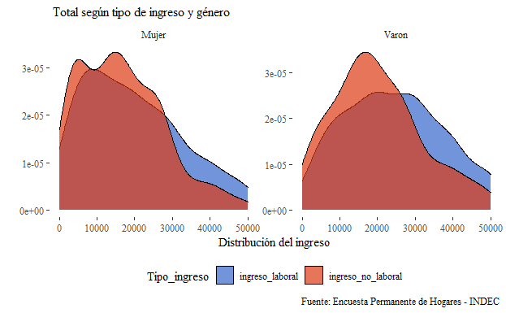

```r
datagraf2 <- datagraf %>% filter(Ingreso !=0)
ggplot(datagraf2, aes(
  x = Ingreso,
  weights = PONDII,
  group = Tipo_ingreso,
  fill = Tipo_ingreso)) +
  geom_density(alpha=0.7,adjust =2)+
  labs(x="Distribución del ingreso", y="",
       title=" Total según tipo de ingreso y género",
       caption = "Fuente: Encuesta Permanente de Hogares - INDEC")+
  scale_x_continuous(limits = c(0,50000))+
  theme_tufte()+
  scale_fill_gdocs()+
  theme(legend.position = "bottom",
        plot.title      = element_text(size=12))+
  facet_wrap(~ CH04, scales = "free") # se distingue por sexo
```

En este tipo de gráficos, importa mucho qué variable se utiliza para *facetear* y qué variable para agrupar, ya que la construcción de la distribución es diferente.

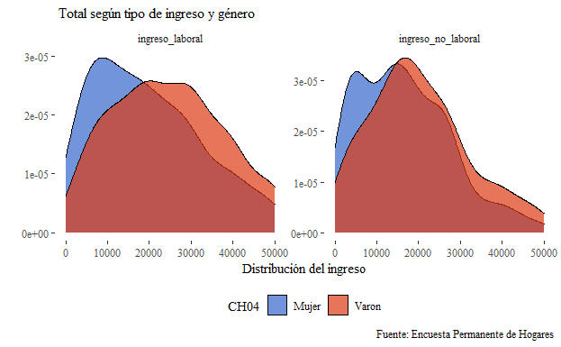

```r
ggplot(datagraf2, aes(
  x = Ingreso,
  weights = PONDII,
  group = CH04,
  fill = CH04)) +
  geom_density(alpha=0.7,adjust =2)+
  labs(x="Distribución del ingreso", y="",
       title=" Total según tipo de ingreso y género",
       caption = "Fuente: Encuesta Permanente de Hogares")+
  scale_x_continuous(limits = c(0,50000))+
  theme_tufte()+
  scale_fill_gdocs()+
  theme(legend.position = "bottom",
        plot.title      = element_text(size=12))+
  facet_wrap(~Tipo_ingreso, scales = "free") # se separa por ingreso
```

El eje y no tiene demasiada interpretabilidad en los Kernel, porque hace a la forma en que se construyen las distribuciones.

### Tendencia (OPCIONAL)

Para realizar estos gráficos, vamos a modificar un poco los datos:

- filtramos los ingresos iguales a 0.
- eliminamos las no respuestas de nivel educativo y las personas con educación especial.
- eliminamos las respuestas de tipo de establecimiento = ‘otros’.
- recodificamos las variables para que tengan nombres más sugestivos:
  - **Nivel educativo** además la convertimos a factor, porque queremos explicitarle el orden de los valores con `levels()`. El “\n”" es un *caracter especial* que permite que el string continúe en la siguiente línea.
  - Sexo.
  - Tipo de establecimiento.

```r
ggdata <- Individual_T120 %>%
  filter(P21>0,
         !is.na(NIVEL_ED),
         NIVEL_ED!=7,
         PP04A !=3) %>%
  mutate(NIVEL_ED = factor(case_when(NIVEL_ED == 1  ~ 'Primaria \n Incompleta', # '\n' significa carriage return, o enter
                                     NIVEL_ED == 2  ~ 'Primaria \n Completa',
                                     NIVEL_ED == 3  ~ 'Secundaria \nIncompleta',
                                     NIVEL_ED == 4  ~ 'Secundaria \nCompleta',
                                     NIVEL_ED == 5  ~ 'Superior \nUniversitaria \nIncompleta',
                                     NIVEL_ED == 6  ~ 'Superior \nUniversitaria \nCompleta',
                                     FALSE          ~ 'Otro'),
                           levels= c('Primaria \n Incompleta',
                                     'Primaria \n Completa',
                                     'Secundaria \nIncompleta',
                                     'Secundaria \nCompleta',
                                     'Superior \nUniversitaria \nIncompleta',
                                     'Superior \nUniversitaria \nCompleta')),
         Sexo     = case_when(CH04 == 1 ~ 'Varón',
                              CH04 == 2 ~ 'Mujer'),
         Establecimiento    = case_when(PP04A == 1 ~ 'Estatal',
                                        PP04A == 2 ~ 'Privado',
                                        FALSE      ~ 'Otro'))

ggdata
```

| CODUSU | ANO4 | TRIMESTRE | NRO_HOGAR | COMPONENTE | H15 | REGION | MAS_500 | AGLOMERADO | PONDERA | CH03 | CH04 | CH05 | CH06 | CH07 | CH08 | CH09 | CH10 | CH11 | CH12 | CH13 | CH14 | CH15 | CH15_COD | CH16 | CH16_COD | NIVEL_ED | ESTADO | CAT_OCUP | CAT_INAC | … |
| --- | --- | --- | --- | --- | --- | --- | --- | --- | --- | --- | --- | --- | --- | --- | --- | --- | --- | --- | --- | --- | --- | --- | --- | --- | --- | --- | --- | --- | --- | --- |
| TQSMNOQRQHLMLPCDEGOIH00654347 | 2020 | 1 | 1 | 1 | 1 | 40 | NA | 18 | 182 | 1 | 1 | 30/01/1991 | 29 | 1 | 4 | 1 | 2 | 0 | 4 | 2 | 3 | 1 | NA | 1 | NA | Secundaria \nIncompleta | 1 | 2 | 0 | … |
| TQRMNORXXHMKKSCDEGOIH00631031 | 2020 | 1 | 1 | 1 | 1 | 40 | NA | 18 | 261 | 1 | 1 | 13/10/1973 | 46 | 2 | 1 | 1 | 2 | 0 | 7 | 1 | NA | 1 | NA | 1 | NA | Superior \nUniversitaria \nCompleta | 1 | 2 | 0 | … |
| TQRMNORXVHJOLOCDEGOIH00625027 | 2020 | 1 | 1 | 3 | 1 | 40 | NA | 18 | 220 | 3 | 1 | 04/11/1985 | 34 | 5 | 4 | 1 | 2 | 0 | 4 | 2 | 3 | 1 | NA | 1 | NA | Secundaria \nIncompleta | 1 | 3 | 0 | … |
| TQRMNORXVHJOLOCDEGOIH00625027 | 2020 | 1 | 1 | 4 | 1 | 40 | NA | 18 | 220 | 3 | 1 | 26/10/1983 | 36 | 5 | 4 | 1 | 2 | 0 | 4 | 1 | NA | 1 | NA | 1 | NA | Secundaria \nCompleta | 1 | 3 | 0 | … |
| TQRMNOPWRHJOLQCDEGOIH00624965 | 2020 | 1 | 1 | 3 | 1 | 40 | NA | 18 | 214 | 3 | 2 | 19/02/1997 | 23 | 5 | 4 | 1 | 2 | 0 | 4 | 1 | NA | 1 | NA | 1 | NA | Secundaria \nCompleta | 1 | 2 | 0 | … |
| TQRMNOPVTHKOKPCDEGOIH00654370 | 2020 | 1 | 1 | 4 | 1 | 40 | NA | 18 | 225 | 3 | 1 | 12/06/1996 | 23 | 1 | 4 | 1 | 2 | 0 | 4 | 2 | 2 | 1 | NA | 1 | NA | Secundaria \nIncompleta | 1 | 3 | 0 | … |
| TQRMNOUQTHKOKPCDEGOIH00654371 | 2020 | 1 | 1 | 1 | 1 | 40 | NA | 18 | 225 | 1 | 1 | 31/01/1984 | 36 | 2 | 4 | 1 | 2 | 0 | 2 | 1 | NA | 1 | NA | 1 | NA | Primaria \n Completa | 1 | 3 | 0 | … |
| TQRMNOXWYHLOKRCDEGOIH00648900 | 2020 | 1 | 1 | 1 | 1 | 40 | NA | 18 | 1024 | 1 | 1 | 02/05/1975 | 44 | 1 | 4 | 1 | 2 | 0 | 4 | 2 | 4 | 1 | NA | 1 | NA | Secundaria \nIncompleta | 1 | 2 | 0 | … |
| TQRMNOQPQHMOKOCDEGLDF00630765 | 2020 | 1 | 1 | 1 | 1 | 41 | NA | 15 | 164 | 1 | 2 | 16/12/1976 | 43 | 1 | 1 | 1 | 2 | 0 | 7 | 1 | NA | 1 | NA | 1 | NA | Superior \nUniversitaria \nCompleta | 1 | 3 | 0 | … |
| TQRMNOQPQHMOKOCDEGLDF00630765 | 2020 | 1 | 1 | 2 | 1 | 41 | NA | 15 | 164 | 2 | 1 | 18/10/1982 | 37 | 1 | 1 | 1 | 2 | 0 | 4 | 1 | NA | 1 | NA | 1 | NA | Secundaria \nCompleta | 1 | 3 | 0 | … |

[output cut: 990 more lines]

Para graficar un suavizado de las series, se utiliza la función [`geom_smooth()`](http://ggplot2.tidyverse.org/reference/geom_smooth.html). Con suavizado nos referimos al gráfico de un modelo realizado sobre los datos, que estima el valor en el punto x,y (para el grupo). Las regresiones lineales son un ejemplo de esto, aunque no el único, ni el que viene por default.

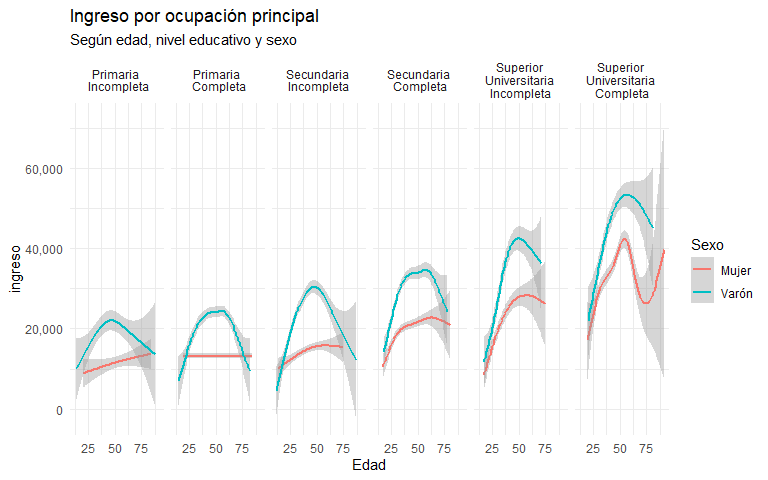

```r
ggplot(ggdata, aes(CH06, P21, colour = Sexo, shape = Sexo, alpha = P21))+
  geom_smooth() +
  labs(
    x = 'Edad',
    y = 'ingreso',
    title = 'Ingreso por ocupación principal',
    subtitle = 'Según edad, nivel educativo y sexo') +
  theme_minimal()+
  scale_y_continuous(labels = comma)+
  scale_alpha(guide = FALSE)+
  facet_grid(.~NIVEL_ED)
```

Si corremos el comando `geom_smooth()` por default, nos advierte que esta utilizando el método GAM, de [general additive models](https://m-clark.github.io/docs/GAM.html).

el **sombreado gris** que envuelve cada línea es el intervalo de confianza de dicho punto (95% por default).

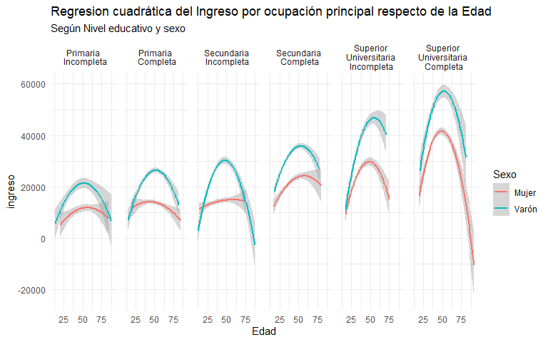

```r
ggplot(ggdata, aes(CH06, P21, colour = Sexo, weight = PONDIIO)) +
  geom_smooth(method = "lm", formula = y ~ poly(x, 2)) +
  labs(x = 'Edad',
       y = 'ingreso',
       title = 'Regresion cuadrática del Ingreso por ocupación principal respecto de la Edad',
       subtitle = 'Según Nivel educativo y sexo') +
  theme_minimal()+
  facet_grid(. ~ NIVEL_ED)
```

Si quisiéramos, además de ver la relación entre ingreso, Edad, Sexo y Nivel educativo, incorporar el tipo de establecimiento,público o privado. Podemos facetear el gráfico por dos variables en lugar de una, lo que crea una **matriz de gráficos** según los cruces.

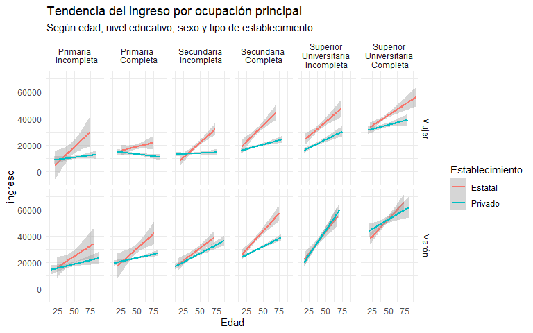

```r
ggplot(ggdata, aes(CH06, P21, colour = Establecimiento, weight = PONDIIO)) +
  geom_smooth(method = "lm") +
  labs(
  x = 'Edad',
  y = 'ingreso',
  title = 'Tendencia del ingreso por ocupación principal',
  subtitle = 'Según edad, nivel educativo, sexo y tipo de establecimiento') +
  theme_minimal()+
  facet_grid(Sexo ~ NIVEL_ED)
```

[^1]: Basado en la [clase](https://diegokoz.github.io/EEA2019/clase%202/Clase%202-%20Tidyverse.nb.html) de Juan Barriola y Diego Kozlowski